# Análisis de Series Temporales

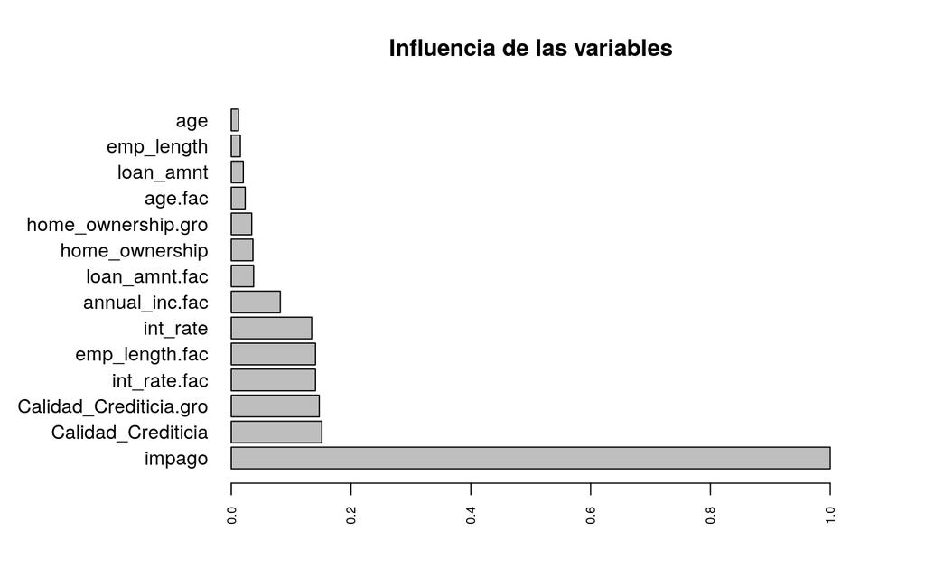

```r
# breaks_adj<- woebin_adj(datos, age, bins)
# loan_amnt=c("3000", "5500", "7000", "11000", "14500", "16500", "21500"),
# int_rate=c(6.5, 8, 11, 15),
# Calidad_Crediticia=c("A", "B", "C", "D%,%E%,%F%,%G"),
# emp_length=c(1.5, 2.5, 6.5, 10.5, 13),
# home_ownership=c("MORTGAGE", "OTHER%,%OWN", "RENT"),
# annual_inc=c(40000, 65000, 95000),
# age=c(23, 24, 38)
# Incorporo las variables binneadas y agrupadas
datos$loan_amnt.fac<- cut(datos$loan_amnt, breaks=c(0, 3000, 5500, 7000, 11000, 14500, 16500, 21500, Inf))
datos$int_rate.fac<- cut(datos$int_rate, breaks=c(0, 6.5, 8, 11, 15, Inf))
datos$emp_length.fac<- cut(datos$int_rate, breaks=c(0, 6.5, 8, 11, 15, Inf))
datos$annual_inc.fac<- cut(datos$annual_inc, c(0, 40000, 65000, 95000, Inf))
datos$age.fac<- cut(datos$age, c(0, 23, 24, 38, Inf))
datos$home_ownership.gro<- droplevels(replace(datos$home_ownership, which(datos$home_ownership == "OWN"), "OTHER"))
datos$Calidad_Crediticia.gro<- droplevels(replace(datos$Calidad_Crediticia,
                                                  which(datos$Calidad_Crediticia %in% c("E", "F", "G")), "D"))
## 2.3 Importancia de las variables ----
# Calcula el V de Cramer
CrossTable(varObjBin) # 88.9% de ceros (NO impago), 11.1% de unos (SI impagos)
##
##
##    Cell Contents
## |-------------------------|
## |                       N |
## |         N / Table Total |
## |-------------------------|
##
##
## Total Observations in Table:  29092
##
##
##           |         0 |         1 |
##           |-----------|-----------|
##           |     25865 |      3227 |
##           |     0.889 |     0.111 |
##           |-----------|-----------|
##
##
##
##
par(mar = c(4.1,10,4.1,4.1))
# Dejo el impago para asegurarme de la calidad de la función
graficoVcramer(datos, datos$impago, "Influencia de las variables")
```

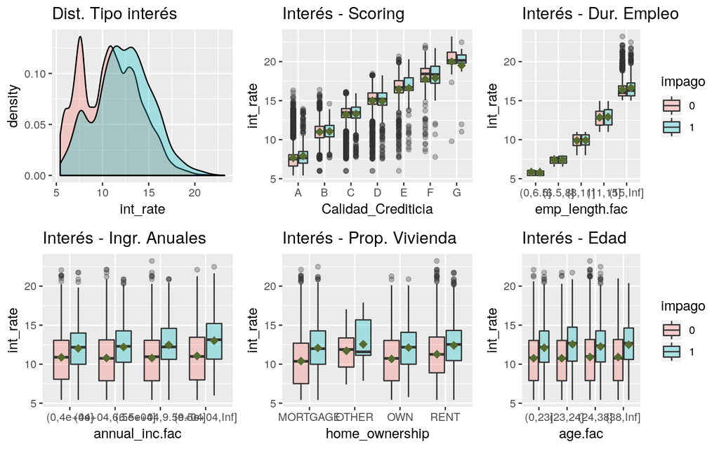

```r
# Hago tres grupos (solo con independientes)
selec.var<- c("Calidad_Crediticia", "int_rate.fac", "emp_length.fac", "annual_inc.fac", "loan_amnt.fac")
selec.var.2<- c("Calidad_Crediticia.gro", "int_rate.fac", "emp_length.fac", "annual_inc.fac", "loan_amnt.fac",
                "home_ownership.gro")

## 2.4 Gráficos para entender los datos ----
# Para las dos variables cuantitativas más relevantes según la V de Cramer
p1<- myDistPlot(datos, "int_rate", "impago", "Dist. Tipo interés")
p2<- myBoxPlot(datos, "Calidad_Crediticia", "int_rate", "impago", "Interés - Scoring", F)
p3<- myBoxPlot(datos, "emp_length.fac", "int_rate", "impago", "Interés - Dur. Empleo", T)
p4<- myBoxPlot(datos, "annual_inc.fac", "int_rate", "impago", "Interés - Ingr. Anuales", F)
p5<- myBoxPlot(datos, "home_ownership", "int_rate", "impago", "Interés - Prop. Vivienda", F)
p6<- myBoxPlot(datos, "age.fac", "int_rate", "impago", "Interés - Edad", T)
gridExtra::grid.arrange(p1, p2, p3, p4, p5, p6, ncol=3, nrow=2)
```

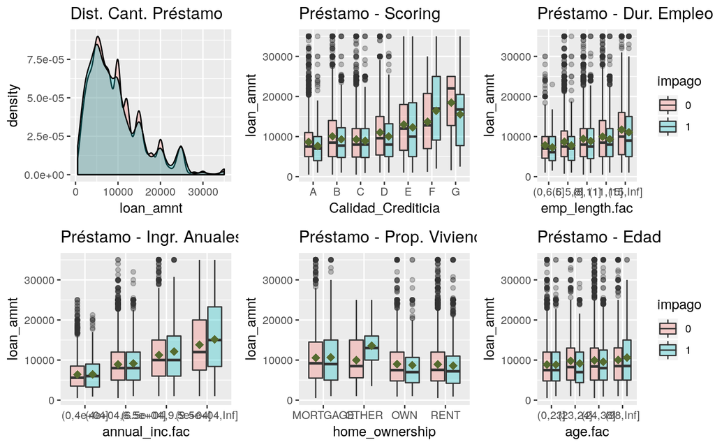

```r
p1<- myDistPlot(datos, "loan_amnt", "impago", "Dist. Cant. Préstamo")
p2<- myBoxPlot(datos, "Calidad_Crediticia", "loan_amnt", "impago", "Préstamo - Scoring", F)
p3<- myBoxPlot(datos, "emp_length.fac", "loan_amnt", "impago", "Préstamo - Dur. Empleo", T)
p4<- myBoxPlot(datos, "annual_inc.fac", "loan_amnt", "impago", "Préstamo - Ingr. Anuales", F)
p5<- myBoxPlot(datos, "home_ownership", "loan_amnt", "impago", "Préstamo - Prop. Vivienda", F)
p6<- myBoxPlot(datos, "age.fac", "loan_amnt", "impago", "Préstamo - Edad", T)
gridExtra::grid.arrange(p1, p2, p3, p4, p5, p6, ncol=3, nrow=2)
```

```r
## 2.5 Transformación de variables ----
welch.out<-onewaytests::welch.test(int_rate ~ impago, data=datos, verbose = F)
welch.out$statistic
## [1] 613.7811
welch.out$p.value # Gran diferencia entre las distribuciones
## [1] 2.130248e-126

welch.out<-onewaytests::welch.test(loan_amnt ~ impago, data=datos, verbose = F)
welch.out$statistic
## [1] 3.680289
welch.out$p.value
## [1] 0.05512978

datos$loan_amnt.log<- log(datos$loan_amnt)
welch.out<-onewaytests::welch.test(loan_amnt.log ~ impago, data=datos, verbose = F)
welch.out$statistic
## [1] 12.06692
welch.out$p.value # Ha mejorado mucho la separación de las distribuciones
## [1] 0.0005187072

# 2.6 Separación train - test ----
datos$aleatoria<- rnorm(nrow(datos))
datos.list<- split_df(datos, y="impago", ratio = 0.7, seed = 12345)
data_train <- datos.list$train
data_test <- datos.list$test
saveRDS(datos, "datos.fin")
saveRDS(data_train, "train")
saveRDS(data_test, "test")
```

Debo de decir que no termino de entender el uso de **Welch test** aquí ya que según he leído se emplea para constrastar similitud entre distribuciones normales, y nosotros estamos empleando una de las variables categoóricas. No obstante no he tenido el tiempo que me hubiera gustado para informarme sobre el test. Así que en la variable para la que el p-valor es dudoso, he probado una transformación y como lo mejora la he incorporado a los datos.

El siguiente paso va a consistir ya en diseñar los modelos, voy a hacer 7 uno con todas las variables, dos con las listas de variables seleccionadas, dos con el criterio de selección de variables AIC, primero en las dos direcciones y luego sólo hacia atrás, y otro modelo haciendo esto mismo con el criterio de selección BIC.

```r
# 3. Estimación ----
# Logistic regresion
# Todas las variables
full <- glm(impago ~ ., family = binomial(link="logit"), data = data_train)
summary(full)
# La primera selección
frml<- as.formula(paste("impago", paste(selec.var, collapse="+"), sep="~"))
m1 <- glm(frml, family = binomial(link="logit"), data = data_train)
summary(m1)
# La segunda selección
frml<- as.formula(paste("impago", paste(selec.var.2, collapse="+"), sep="~"))
m2 <- glm(frml, family = binomial(link="logit"), data = data_train)
summary(m2)

# 3.1 Modelos basados en criterios de selección de variables ----
null<- glm(impago ~ 1, family = binomial(link="logit"), data = data_train)
mAIC<-step(null, scope=list(lower=null, upper=full), direction="both")
mAIC.b<-step(full, scope=list(lower=null, upper=full), direction="backward")
mBIC<-step(null, scope=list(lower=null, upper=full), direction="both", k=log(nrow(data_train)))
mBIC.b<-step(full, scope=list(lower=null, upper=full), direction="backward",k=log(nrow(data_train)))

# 3.2 Save, so you can continue from this point
saveRDS(full, "mfull")
saveRDS(m1, "m1")
saveRDS(m2, "m2")
saveRDS(mAIC, "mAIC")
saveRDS(mAIC.b, "mAICb")
saveRDS(mBIC, "mBIC")
saveRDS(mBIC.b, "mBICb")
```

De momento los modelos ya están entrenados. Vemos que pese a las *dummies* el número de variables no se ha disparado, lo interesante es ahora hacer validación cruzada repetida y ver cuál es el modelo que mejor se comporta

```r
# 3.2 Validacion cruzada repetida ----
auxVarObj<-datos$impago
datos$impago<-make.names(datos$impago) #formateo la variable objetivo para que funcione el codigo
modelos.nombres = c("full", "m1", "m2", "mAIC", "mAIC.b", "mBIC", "mBIC.b")
modelos<-sapply(list(full, m1, m2, mAIC, mAIC.b, mBIC, mBIC.b),formula)
total<- c()
for (i in 1:length(modelos)){
  set.seed(1712)
  vcr<-train(as.formula(modelos[[i]]), data = datos,
             method = "glm", family="binomial", metric = "ROC",
             trControl = trainControl(method="repeatedcv", number=5, repeats=20,
                                      summaryFunction=twoClassSummary,
                                      classProbs=TRUE,returnResamp="all")
  )
  total<-rbind(total,data.frame(roc=vcr$resample[,1], modelo=rep(modelos.nombres[i],
                                                                 nrow(vcr$resample))))
}

comparativa<- data.frame(row.names = unique(total$modelo))
comparativa$mean_ROC<- aggregate(roc~modelo, data = total, mean)$roc
comparativa$std_ROC<- aggregate(roc~modelo, data = total, sd)$roc
comparativa$variables<- sapply(list(full, m1, m2, mAIC, mAIC.b, mBIC, mBIC.b),
                               function (x){length(coef(x))})
comparativa<- comparativa[order(comparativa$mean_ROC),]


saveRDS(comparativa, "comparativa")
saveRDS(total, "total")
```

|  | mean_ROC | std_ROC | variables |
| --- | --- | --- | --- |
| mBIC.b | 0.6520884 | 0.008602915 | 10 |
| mBIC | 0.6529737 | 0.008482166 | 8 |
| m2 | 0.6544392 | 0.008158751 | 24 |
| m1 | 0.6556332 | 0.008389960 | 25 |
| full | 0.6556939 | 0.008204686 | 43 |
| mAIC | 0.6565449 | 0.008136639 | 25 |
| mAIC.b | 0.6566073 | 0.008321733 | 21 |

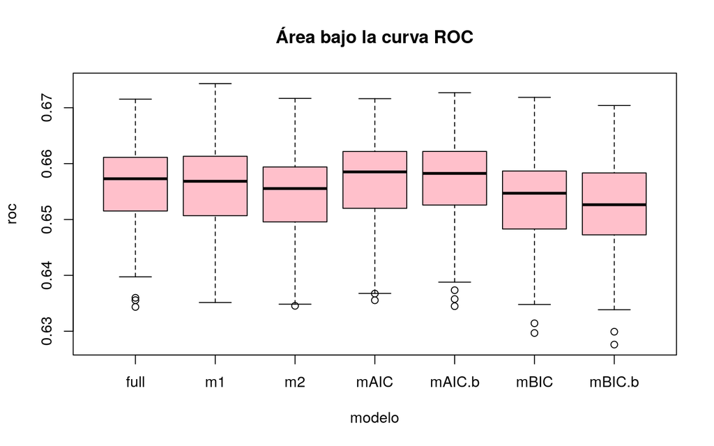

Lo primero que conviene notar es que todos los modelos presentan una área bajo la curva ROC de muy similar, entre el menor y el mayor valor hay tan solo 0.0045189. A priori lo mejor sería coger el de menor número de variables, sin embargo, yo he seleccionado el modelo **mAIC.b** que con 21 variables mejora en 4 milésimas a aquellos que presentan 10 variables menos y a todos los que presentan más variables. Tal vez 10 variables para 4 milésimas no merecen la pena, pero 21 variables no son demasiadas.

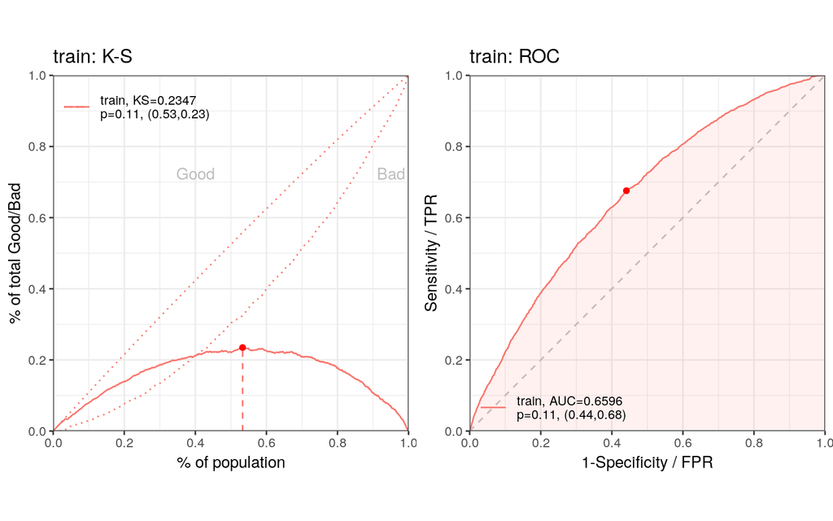

```r
## 3.3 Performance ----
# predicted proability
train_pred <- predict(mAIC.b, type='response', data_train) # type='response', Para predecir probabilidad
test_pred <- predict(mAIC.b, type='response', data_test)

# ks & roc plot
perf_train<- perf_eva(train_pred, make.names(data_train$impago), title = "train")
## [INFO] The threshold of confusion matrix is 0.1292.
```

```r
perf_test<- perf_eva(test_pred, make.names(data_test$impago), title = "test")
## [INFO] The threshold of confusion matrix is 0.1282.
```

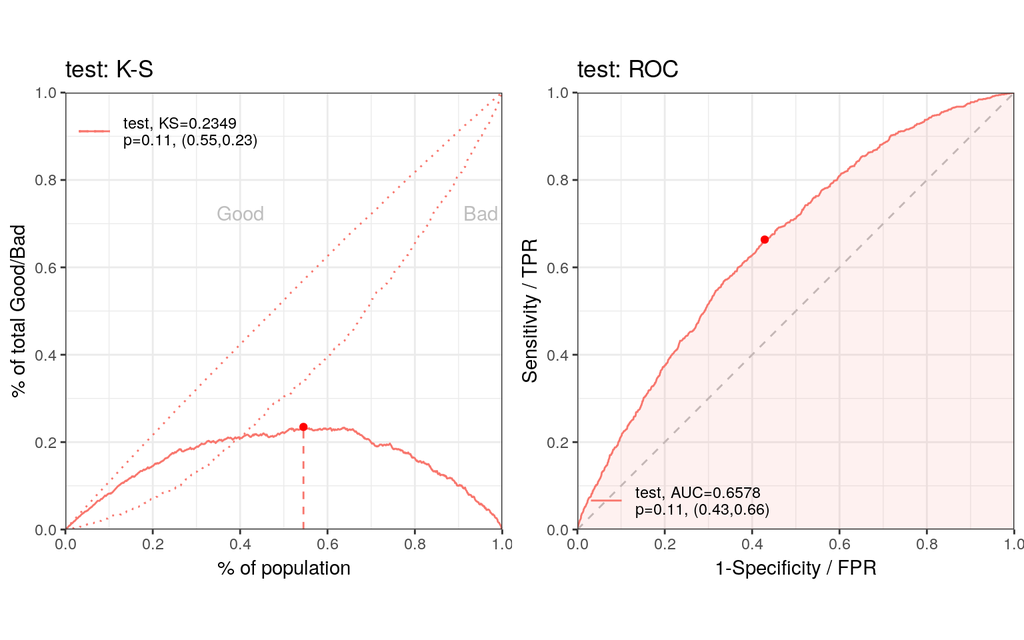

```r
cutoff<-perf_test$binomial_metric$test$KS
test_predconf<-ifelse(test_pred<cutoff,0,1)

# Create confusion matrix
conf_matrix<-table(data_test$impago,test_predconf)
data.frame("NO_imp"=conf_matrix[1,], "SI_imp"=conf_matrix[2,], row.names = c("0", 1))
```

|  | NO_imp | SI_imp |
| --- | --- | --- |
| 0 | 7408 | 885 |
| 1 | 248 | 78 |

```r
accuracy<-(conf_matrix[1,1]+conf_matrix[2,2])/sum(conf_matrix)

# score
card <- scorecard(bins, mAIC.b)

# credit score, only_total_score = TRUE
train_score <- scorecard_ply(data_train, card, print_step=0)
test_score <- scorecard_ply(data_test, card, print_step=0)

# psi (population stability index)
# Es una medida de diferencia en la distribución de dos muestras
psi<- perf_psi(
  score = list(train = train_score, test = test_score),
  label = list(train = data_train[,"impago"], test = data_test[, "impago"]),
  x_limits = c(250, 700),
  x_tick_break = 50
)

# Less than 0.1 Insignificant change    No action required
# 0.1 – 0.25    Some minor change   Check other scorecard monitoring metrics
# Greater than 0.25 Major shift in population   Need to delve deeper
```

Podemos ver que el **PSI** es: 3.610^{-4}, suficientemente bajo como para dar por exitoso el modelo de scoring, que presenta además una prescisión sobre el set de test de 86.855% que es bastante elevada, así que debemos darnos por satisfechos.

# Muchas gracias

Pese a que el set de ejercicios me ha parecido desproporcionadamente largo, creo que el esfuerzo ha merecido la pena, gracias por su trabajo.